# How Capitalism Produces Political Backlash

Stephen Weymouth

Dean’s Professor

2026-11-09

# On September 15, 2008, Lehman Brothers filed the largest bankruptcy in U.S. history. Within weeks governments were rescuing the banks.

## Capitalism’s popularity has fallen in the U.S.

[figure not shown]

Gallup, [Socialism’s Positive Rating Tops 40% for First Time](https://news.gallup.com/poll/714653/socialism-positive-rating-tops-first-time.aspx), September 2026.

Small business still has a 95 percent positive rating, while big business has fallen to 35 percent.

Why would people in the world’s largest market economy think less of capitalism?

## Young adults now rate socialism above capitalism

Among adults under 30, capitalism’s positive rating fell from 68 percent in 2010 to 45 percent in 2018.

From 2010 to 2026 Democrats’ rating of capitalism fell from 51 to 35 percent, while Republicans’ rose.

Today’s young adults grew up during the crisis or the slow recovery that followed it.

[figure not shown]

Gallup, [Socialism’s Positive Rating Tops 40% for First Time](https://news.gallup.com/poll/714653/socialism-positive-rating-tops-first-time.aspx), September 2026.

## Your IB Voice

The crisis and capitalism

Positive views of capitalism in the U.S. have slipped since 2010, most among the young. Using one piece of evidence from Wolf, explain how the 2008 financial crisis could have changed the way people judge capitalism.

**10 minutes** · Individual · Notes permitted

# What did the crisis cost households?

## Output per person never returned to its old path

[figure not shown]

World Bank, [World Development Indicators](https://data.worldbank.org/indicator/NY.GDP.PCAP.KD), 2026: GDP per capita, constant 2015 dollars; trend fitted to 1990–2007.

After 2009 the U.S. economy grew again, but never fast enough to return to its old path.

The U.K. fell furthest behind; Wolf judges its loss larger and longer lasting than either world war or the Great Depression caused.

The crisis lowered the path that living standards were expected to follow, not just output for a year or two.

## Most households’ market incomes stopped rising

On average across 25 rich countries, about two-thirds of households earned no more from work and savings, after inflation, in 2014 than in 2005.

These are incomes before taxes and government transfers.

*Economic stagnation* is a long period in which output and most people’s real incomes barely grow.

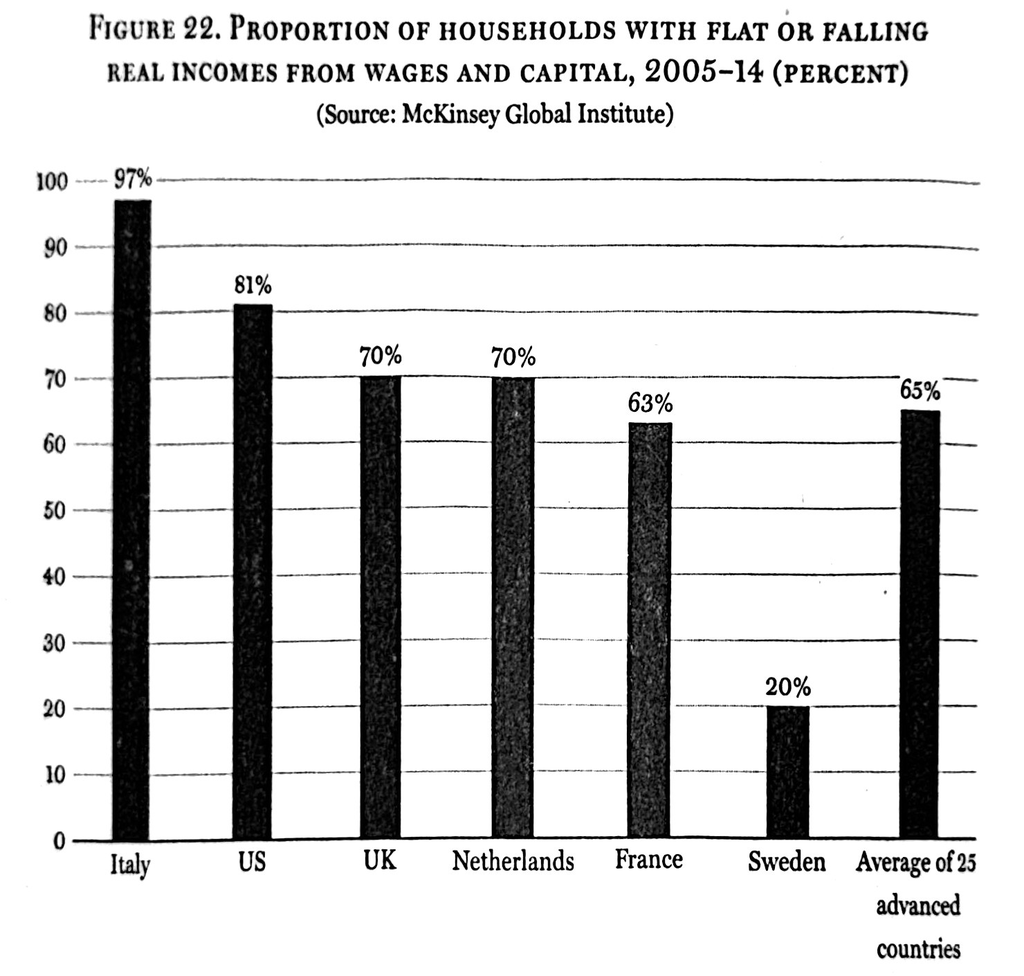

Wolf, *The Crisis of Democratic Capitalism*, 2023, Figure 22, p. 102, from McKinsey Global Institute.

## Governments cut deficits during a weak recovery

[figure not shown]

Redrawn from Wolf, *The Crisis of Democratic Capitalism*, 2023, Figure 24, p. 104 (IMF data); values read from the figure.

Each arrow runs from a government’s largest structural deficit between 2007 and 2017, which for most countries came in 2009–11, to its smallest deficit afterward, mostly in 2013–17.

A structural deficit is the deficit a government would run if the economy were at full capacity.

*Austerity* is cutting spending or raising taxes to shrink a budget deficit.

# Why did the crisis cost so much trust?

## Banks were rescued while families lost homes

[figure not shown]

Paulson and Bernanke, Congressional Testimony, 2008

In October 2008 Congress authorized $700 billion to rescue financial firms.

By 2013 about 4.8 million homes had been lost to foreclosure, yet only one Wall Street executive went to prison (Credit Suisse’s global head of structured credit).

A *corporate bailout* uses public money or guarantees to keep a failing firm alive.

## Confidence in banks collapsed after 2008

[figure not shown]

Gallup, [Confidence in Institutions](https://news.gallup.com/poll/1597/confidence-institutions.aspx), 2026: banks.

Confidence in banks halved between 2007 and 2009 and has not returned to its precrisis level.

Wolf argues that a visible failure, followed by a rescue of those blamed for it, caused the distrust.

## Home prices fell by more than a quarter

[figure not shown]

S&P Dow Jones Indices, [S&P CoreLogic Case-Shiller U.S. National Home Price Index](https://fred.stlouisfed.org/series/CSUSHPINSA), via FRED, 2026.

For most homeowners the house was their largest asset, so the fall erased much of their wealth.

Owners who owed more than their homes were worth could not sell or refinance, and millions lost them to foreclosure.

The housing crash turned a banking crisis into a loss that ordinary families felt directly.

## The rescue that made money

The Treasury got back more from the banks it rescued than it put in, while TARP grants to help homeowners avoid foreclosure cost $31 billion. Why did the bank rescue still cost so much trust?

## Trust in the federal government has stayed low

[figure not shown]

Pew Research Center, [Public Trust in Government: 1958–2025](https://www.pewresearch.org/politics/2025/12/04/public-trust-in-government-1958-2025/), 2025; 2008 is the average of three polls.

Trust in the federal government fell long before 2008, and the crisis kept it near its lowest levels.

*Democratic capitalism* pairs a market economy with elected government, and each depends on citizens’ trust.

How can the crisis of democratic capitalism be overcome?

# In 2011 “Occupy Wall Street” protesters camped near Wall Street and said they spoke for the 99 percent.

# Why did the backlash come after 2008?

## Populist parties in Europe gained after the crisis

[figure not shown]

Redrawn from Wolf, *The Crisis of Democratic Capitalism*, 2023, Figure 25, p. 108 (data from Roberto Foa); values read from the figure.

In southern Europe, where the euro crisis hit hardest, populist support was flat for a decade and rose most after that crisis began.

*Populism* casts politics as a contest between a virtuous people and a corrupt elite.

## The foreign-born share grew less in the U.S.

Political scientists Inglehart and Norris call populism a cultural backlash against social change.

Wolf replies that these changes ran for decades, so culture alone cannot explain why the backlash came when it did.

Wolf argues that immigration became far more political in the U.S. only after the crisis.

[figure not shown]

World Bank, [World Development Indicators](https://data.worldbank.org/indicator/SM.POP.TOTL.ZS), 2026: international migrant stock, from UN DESA.

## Financial crises

[figure not shown]

Funke, Schularick, and Trebesch, “Going to Extremes: Politics after Financial Crises, 1870–2014,” *European Economic Review*, 2016.

In the five years after a financial crisis, far-right parties’ vote share grows by about a third: a party that won 10 percent before the crisis wins about 13 percent after it. Ordinary recessions do not produce this jump.

Why would a banking crisis matter more?

# What do your friends mean by socialism?

## Your friends and socialism

1. **Think** of a friend or acquaintance who says socialism would work better than capitalism.
2. **Describe** what that person most wants changed. Share with a partner.
3. **Discuss** whether the complaint fits Wolf’s explanation - or if something else is the main factor.
4. **Decide** what 1) a company and 2) a government could do to earn that person’s trust.

**15 minutes** · Individual then pairs · Reading permitted

## Discussion

In 2026, 69 percent of adults aged 18 to 34 viewed “free enterprise” positively, but only 43 percent viewed capitalism positively. What does that gap tell us about what some young people don’t like?

## Module 7 takeaways

How does globalization produce political backlash?

Offshoring raises national income through wage arbitrage, but the losses fall on particular workers.

Those losses spill over into the local economies where the workers live, and those places turned to populists.

After 2008 economic stagnation left most households’ earnings flat for years.

A corporate bailout rescued the banks while families lost homes and jobs, which turned disappointment into distrust of elites.

This distrust weakens democratic capitalism; young adults now rate socialism above capitalism.